# Project 3

```python
import pandas as pd
import numpy as np
import seaborn as sns
import sklearn
```

```python
data = pd.read_csv("08_gap-every-five-years.tsv", sep='\t')
data.head()
```

|  | country | continent | year | lifeExp | pop | gdpPercap |
| --- | --- | --- | --- | --- | --- | --- |
| 0 | Afghanistan | Asia | 1952 | 28.801 | 8425333 | 779.445314 |
| 1 | Afghanistan | Asia | 1957 | 30.332 | 9240934 | 820.853030 |
| 2 | Afghanistan | Asia | 1962 | 31.997 | 10267083 | 853.100710 |
| 3 | Afghanistan | Asia | 1967 | 34.020 | 11537966 | 836.197138 |
| 4 | Afghanistan | Asia | 1972 | 36.088 | 13079460 | 739.981106 |

### Exercise 1

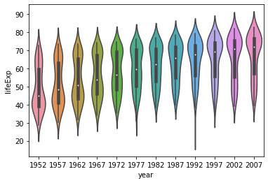

```python
sns.violinplot(x="year",y="lifeExp",data=data)
```

#### Question 1

There is a clear general trend of increasing life expectancy with time. This trend seems to be linear.

#### Question 2

In the years closer to 1952, the results seem strongly skewed right but still slightly bimodal. As we get close to the 1960s we see a strong bimodal tendancy. As we get closer to 2007, the data is skewed left and loses its bomodality as well.

#### Question 3

I believe that we will be able to reject the null hypothesis of no relationship between life expectancy and year, as there seems to be a clear increase in life epentency over time

#### Question 4

I believe that the residuls will be very close to zero across the years. The more skewed the data for that year is, the larger its residual will be. The shapes of the violins should be effectively the same.

#### Question 5

Four assumptions:

1. Linearity

As shown by the graph above, it is fair to assume that the relationship between mean life expectancy and year is linear.

1. Homoscedasticity

There is one is tricky, as this has reason to change over time. In this time window however this changing varaiance in residuals across years doesnt seem to be a large factor.

1. Independence

It makes sense to asusme independace in life expectancy across years.

1. Normality

With such a large sample size, it is fair to assume that Y is most likely normally distributed. Some skew might be in effect but most observations should be very close to normal.

By definition, if the line is actually the line of best fit (assuming linear model), around 50% of the residuals will have a negative value, and 50% will have a positive value. The sum of all the residuals should be 0. The shape should of the violins should be the same as the frequency of data points around a certain value should have the same frequency in its residuals.

### Exercise 2

```python
import statsmodels.api as sm
from statsmodels.formula.api import ols
model = ols(formula="lifeExp ~ year ", data=data).fit()
model.summary()
```

OLS Regression Results

| Dep. Variable: | lifeExp | R-squared: | 0.190 |
| --- | --- | --- | --- |
| Model: | OLS | Adj. R-squared: | 0.189 |
| Method: | Least Squares | F-statistic: | 398.6 |
| Date: | Wed, 17 Nov 2021 | Prob (F-statistic): | 7.55e-80 |
| Time: | 11:47:30 | Log-Likelihood: | -6597.9 |
| No. Observations: | 1704 | AIC: | 1.320e+04 |
| Df Residuals: | 1702 | BIC: | 1.321e+04 |
| Df Model: | 1 |  |  |
| Covariance Type: | nonrobust |  |  |

|  | coef | std err | t | P>\|t\| | [0.025 | 0.975] |
| --- | --- | --- | --- | --- | --- | --- |
| Intercept | -585.6522 | 32.314 | -18.124 | 0.000 | -649.031 | -522.273 |
| year | 0.3259 | 0.016 | 19.965 | 0.000 | 0.294 | 0.358 |

| Omnibus: | 386.124 | Durbin-Watson: | 0.197 |
| --- | --- | --- | --- |
| Prob(Omnibus): | 0.000 | Jarque-Bera (JB): | 90.750 |
| Skew: | -0.268 | Prob(JB): | 1.97e-20 |
| Kurtosis: | 2.004 | Cond. No. | 2.27e+05 |

Notes:  
[1] Standard Errors assume that the covariance matrix of the errors is correctly specified.  
[2] The condition number is large, 2.27e+05. This might indicate that there are  
strong multicollinearity or other numerical problems.

#### Question 6

According to the model summary, it seems that life expectancy increases by around 1/3 of a year for every year that passes.

#### Question 7

It looks like the p-value for both variables is essentailly 0. This means that there is an exeedingly small probability that these two variables have no relationship with each other. This allows us to reject the null hypothesis mentioned earlier.

### Exercise 3

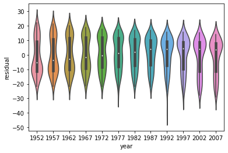

```python
data["residual"] = data["lifeExp"] - model.predict()
sns.violinplot(x="year",y="residual",data=data)
```

### Exercise 4

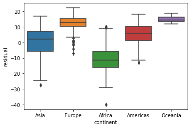

```python
sns.boxplot(x="continent", y="residual", data = data)
```

#### Question 9

I think there is dependance between model residual and continent. If grouped by continents, the line of best fit for each continent will have smaller residuals than the ones generated for the dataset that generalizes over all continents. Contolling for the differences in residuals across different countries will be important in regression analysis.

### Exercise 5

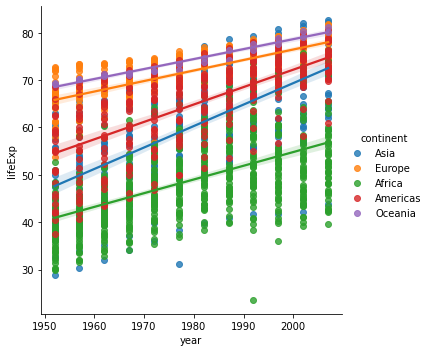

```python
sns.lmplot(x="year", y="lifeExp", hue="continent", data=data)
```

### Question 10

We would need to have an interaction term because it is clear that the slope of the different continent lines are different. The interaction term makes sure that a linear model can account for this.

### Exercise 6

```python
interaction_linreg = ols(formula = "lifeExp ~ continent * year + continent + year", data = data).fit()
interaction_linreg.summary()
```

OLS Regression Results

| Dep. Variable: | lifeExp | R-squared: | 0.693 |
| --- | --- | --- | --- |
| Model: | OLS | Adj. R-squared: | 0.691 |
| Method: | Least Squares | F-statistic: | 424.3 |
| Date: | Wed, 17 Nov 2021 | Prob (F-statistic): | 0.00 |
| Time: | 11:47:31 | Log-Likelihood: | -5771.9 |
| No. Observations: | 1704 | AIC: | 1.156e+04 |
| Df Residuals: | 1694 | BIC: | 1.162e+04 |
| Df Model: | 9 |  |  |
| Covariance Type: | nonrobust |  |  |

|  | coef | std err | t | P>\|t\| | [0.025 | 0.975] |
| --- | --- | --- | --- | --- | --- | --- |
| Intercept | -524.2578 | 32.963 | -15.904 | 0.000 | -588.911 | -459.605 |
| continent[T.Americas] | -138.8484 | 57.851 | -2.400 | 0.016 | -252.315 | -25.382 |
| continent[T.Asia] | -312.6330 | 52.904 | -5.909 | 0.000 | -416.396 | -208.870 |
| continent[T.Europe] | 156.8469 | 54.498 | 2.878 | 0.004 | 49.957 | 263.737 |
| continent[T.Oceania] | 182.3499 | 171.283 | 1.065 | 0.287 | -153.599 | 518.298 |
| year | 0.2895 | 0.017 | 17.387 | 0.000 | 0.257 | 0.322 |
| continent[T.Americas]:year | 0.0781 | 0.029 | 2.673 | 0.008 | 0.021 | 0.135 |
| continent[T.Asia]:year | 0.1636 | 0.027 | 6.121 | 0.000 | 0.111 | 0.216 |
| continent[T.Europe]:year | -0.0676 | 0.028 | -2.455 | 0.014 | -0.122 | -0.014 |
| continent[T.Oceania]:year | -0.0793 | 0.087 | -0.916 | 0.360 | -0.249 | 0.090 |

| Omnibus: | 27.121 | Durbin-Watson: | 0.242 |
| --- | --- | --- | --- |
| Prob(Omnibus): | 0.000 | Jarque-Bera (JB): | 44.106 |
| Skew: | -0.121 | Prob(JB): | 2.65e-10 |
| Kurtosis: | 3.750 | Cond. No. | 2.09e+06 |

Notes:  
[1] Standard Errors assume that the covariance matrix of the errors is correctly specified.  
[2] The condition number is large, 2.09e+06. This might indicate that there are  
strong multicollinearity or other numerical problems.

#### Question 11

All parameters seem to be significantly different from zero except the parameters associated with Oceania. All other parameters have a p value less than alpha = .05. A potential reason for this difference is that Oceania may be considered less significant than the others when considereing all other parameters contributions.

#### Question 12

year 0.2895  
continent[T.Americas]:year - 0.0781  
continent[T.Asia]:year - 0.1636  
continent[T.Europe]:year - -0.0676 continent[T.Oceania]:year - -0.0793

The actual differences are closer to the following (slopes taken from graph)

Africa: .291 yr/yr

Asia: .436 yr/yr

Americas: .345 yr/yr

Europe: .200 yr/yr

Oceania: .200 yr/yr

### Exercise 7

```python
interaction_linreg.fvalue
```

```
424.27290234006927
```

```python
model.fvalue
```

```
398.6047457117635
```

#### Question 13

The model with the interaction term has a higher f value, but this is to be expected as it has a higher degree of freedom. If we look at the p values of the different terms, we see that all of them except the ones for Oceania are significant. It makes complete sense that the fvalue for the model with the interaction term would be higher as it can fit the data better. I think it is fair to say that the interaction model is significantly better than the year only model, but the actual value representations the parameter coefficients have may be innacurate, as evidenced by my answer to Question 12.

### Exercise 8

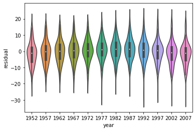

```python
data["residual"] = data["lifeExp"] - interaction_linreg.predict()
sns.violinplot(x="year",y="residual",data=data)
```

[figure not shown]

```python
data["fitted"] = interaction_linreg.predict()
sns.violinplot(x="fitted",y="residual",data=data)
```

Four assumptions:

1. Linearity

As shown by the graph above, it is fair to assume that the relationship between mean life expectancy and year is linear.

1. Homoscedasticity

It looks like this is actually not met. Variance in residuals seems to decrease with x as it increases.

1. Independence

It makes sense to asusme independace in life expectancy across years.

1. Normality

With such a large sample size, it is fair to assume that Y is most likely normally distributed. Some skew might be in effect but most observations should be very close to normal.